# Tugas 2 Analisis Regresi

# 1. Deskripsi Data

## a. Baca data

```r
data_tugas <- read.csv2("C:\\Users\\ASUS\\OneDrive\\문서\\DAFFA\\IPB\\STK\\ANREG\\DATA RUMAH JABODETABEK ANREG.csv")

#ganti jadi numerik
data_tugas[] <- lapply(data_tugas, function(x) as.numeric(as.character(x)))
str(data_tugas)
```

```
## 'data.frame':    1378 obs. of  6 variables:
##  $ price_in_rp     : num  7.00e+10 6.90e+10 6.90e+10 5.50e+10 4.51e+10 ...
##  $ bedrooms        : num  5 4 4 12 12 12 5 4 4 6 ...
##  $ bathrooms       : num  5 4 5 12 12 12 4 3 2 6 ...
##  $ land_size_m2    : num  680 475 474 2050 3475 ...
##  $ building_size_m2: num  1200 1200 1200 1500 1440 1440 470 900 938 1300 ...
##  $ building_age    : num  9 1 1 12 14 14 27 7 7 8 ...
```

## b. Sumber Data

Didapatkan dari website Rumah123 pada tahun 2022 di area Jabodetabek

## c. Deskripsi Variabel

Dataset ini terdiri dari 6 variabel utama:

price_in_rp (Y): Harga jual properti dalam satuan Rupiah (IDR).

bedrooms (X1): Jumlah kamar tidur yang tersedia di dalam rumah.

bathrooms (X2): Jumlah kamar mandi yang tersedia di dalam rumah.

land_size_m2 (X3): Luas tanah properti dalam satuan meter persegi (m²).

building_size_m2 (X4): Luas bangunan properti dalam satuan meter persegi (m²).

building_age (X5): Usia bangunan sejak selesai dibangun atau direnovasi terakhir (dalam tahun).

## d. Statistik Deskriptif

```r
summary(data_tugas)
```

```
##   price_in_rp           bedrooms        bathrooms       land_size_m2
##  Min.   :7.500e+07   Min.   : 1.000   Min.   : 1.000   Min.   :  12.0
##  1st Qu.:7.250e+08   1st Qu.: 2.000   1st Qu.: 2.000   1st Qu.:  72.0
##  Median :1.420e+09   Median : 3.000   Median : 2.000   Median : 100.0
##  Mean   :3.467e+09   Mean   : 3.172   Mean   : 2.483   Mean   : 171.8
##  3rd Qu.:3.650e+09   3rd Qu.: 4.000   3rd Qu.: 3.000   3rd Qu.: 180.0
##  Max.   :7.000e+10   Max.   :12.000   Max.   :13.000   Max.   :4445.0
##
##  building_size_m2  building_age
##  Min.   :  24.0   Min.   : 0.000
##  1st Qu.:  60.0   1st Qu.: 0.000
##  Median : 105.0   Median : 1.000
##  Mean   : 167.4   Mean   : 4.005
##  3rd Qu.: 200.0   3rd Qu.: 6.000
##  Max.   :1500.0   Max.   :49.000
##                   NA's   :54
```

```r
# Mengisi NA bulding age dengan nilai tengah (Median)
data_tugas$building_age[is.na(data_tugas$building_age)] <- median(data_tugas$building_age, na.rm = TRUE)
```

standar Deviasi

```r
std_devs <- sapply(data_tugas, sd, na.rm = TRUE)

hasil_sd <- data.frame(
  Variabel = names(std_devs),
  Standar_Deviasi = std_devs
)
print(hasil_sd)
```

```
##                          Variabel Standar_Deviasi
## price_in_rp           price_in_rp    6.189233e+09
## bedrooms                 bedrooms    1.153517e+00
## bathrooms               bathrooms    1.298030e+00
## land_size_m2         land_size_m2    2.659968e+02
## building_size_m2 building_size_m2    1.789637e+02
## building_age         building_age    6.604742e+00
```

## e. Visualisasi Data

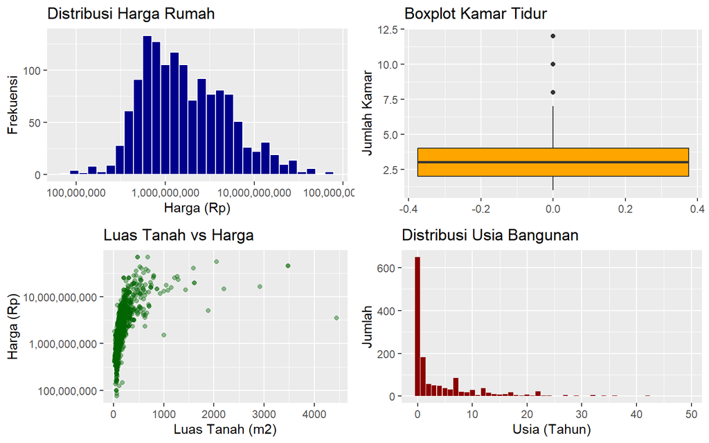

```r
library(ggplot2)
library(gridExtra)

# Grafik 1: Histogram Harga (Skala Log)
p1 <- ggplot(data_tugas, aes(x = price_in_rp)) +
  geom_histogram(fill = "darkblue", color = "white", bins = 30) +
  scale_x_log10(labels = scales::comma) +
  labs(title = "Distribusi Harga Rumah", x = "Harga (Rp)", y = "Frekuensi")

# Grafik 2: Boxplot Kamar Tidur
p2 <- ggplot(data_tugas, aes(y = bedrooms)) +
  geom_boxplot(fill = "orange") +
  labs(title = "Boxplot Kamar Tidur", y = "Jumlah Kamar")

# Grafik 3: Scatter Plot Luas Tanah vs Harga
p3 <- ggplot(data_tugas, aes(x = land_size_m2, y = price_in_rp)) +
  geom_point(alpha = 0.4, color = "darkgreen") +
  scale_y_log10(labels = scales::comma) +
  labs(title = "Luas Tanah vs Harga", x = "Luas Tanah (m2)", y = "Harga (Rp)")

# Grafik 4: Bar Chart Usia Bangunan
p4 <- ggplot(data_tugas, aes(x = building_age)) +
  geom_bar(fill = "darkred") +
  labs(title = "Distribusi Usia Bangunan", x = "Usia (Tahun)", y = "Jumlah")

grid.arrange(p1, p2, p3, p4, ncol = 2)
```

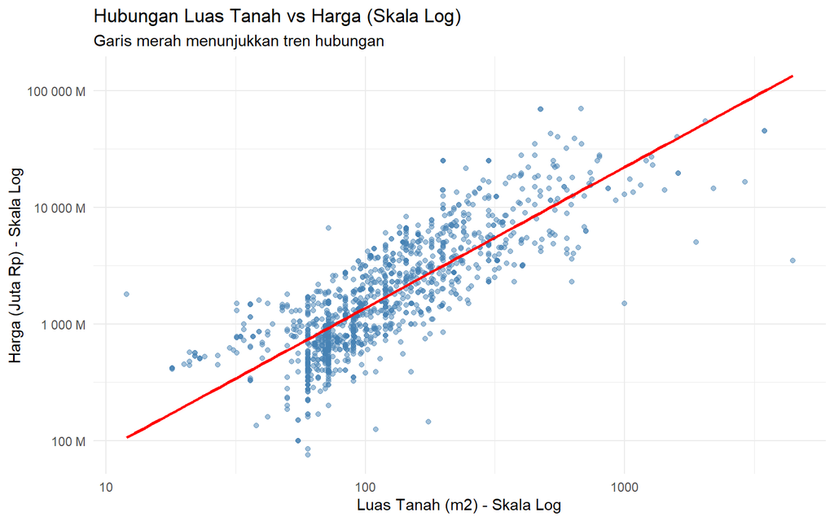

```r
library(scales)
ggplot(data_tugas, aes(x = land_size_m2, y = price_in_rp)) +
  geom_point(alpha = 0.5, color = "steelblue") +
  # Menggunakan skala LOG
  scale_y_log10(labels = unit_format(unit = "M", scale = 1e-6)) +
  scale_x_log10() +
  # Menambahkan garis tren untuk melihat hubungan
  geom_smooth(method = "lm", color = "red", se = FALSE) +
  labs(
    title = "Hubungan Luas Tanah vs Harga (Skala Log)",
    subtitle = "Garis merah menunjukkan tren hubungan",
    x = "Luas Tanah (m2) - Skala Log",
    y = "Harga (Juta Rp) - Skala Log"
  ) +
  theme_minimal()
```

# 2. Eksplorasi Data

## a. hubungan antara variabel Harga Rumah dan masing masing variabel prediktor

### Bedroom

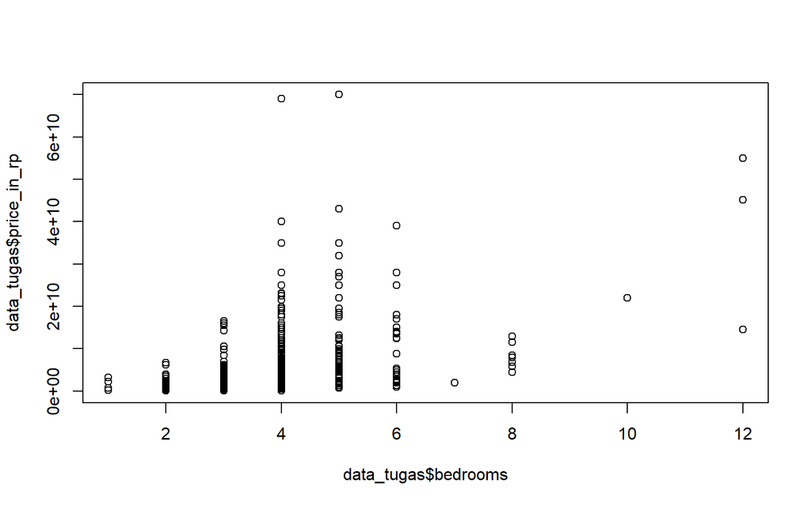

```r
plot(data_tugas$bedrooms, data_tugas$price_in_rp)
```

Grafik menunjukkan bahwa sebagian besar rumah memiliki 2 hingga 6 kamar tidur dengan harga yang mayoritas berkumpul di bawah 20 miliar Rupiah. Meskipun ada kecenderungan harga meningkat seiring bertambahnya jumlah kamar, hubungannya tidak linear sempurna karena adanya variasi harga yang sangat lebar (heteroskedastisitas) dan beberapa outlier ekstrem yang mencapai 70 miliar Rupiah pada kategori kamar tertentu.

### bathrooms

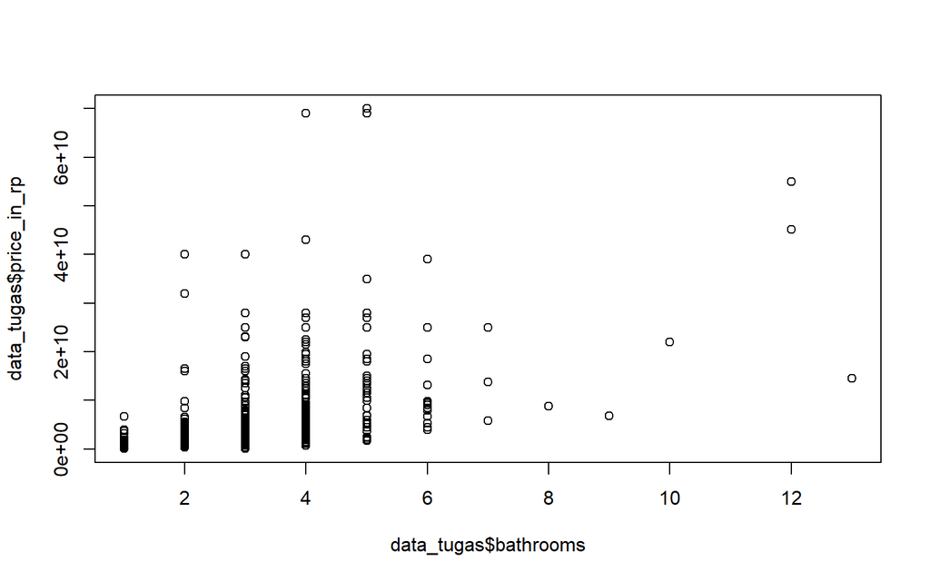

```r
plot(data_tugas$bathrooms, data_tugas$price_in_rp)
```

Terdapat korelasi positif antara jumlah kamar mandi dan harga rumah, di mana harga cenderung naik seiring bertambahnya fasilitas tersebut. Data didominasi oleh rumah dengan 1–5 kamar mandi, namun muncul outlier harga yang sangat tinggi (di atas 60 miliar) pada kategori tertentu. Sebaran vertikal yang lebar menunjukkan bahwa jumlah kamar mandi bukan satu-satunya faktor penentu harga yang dominan.

### Luas Tanah

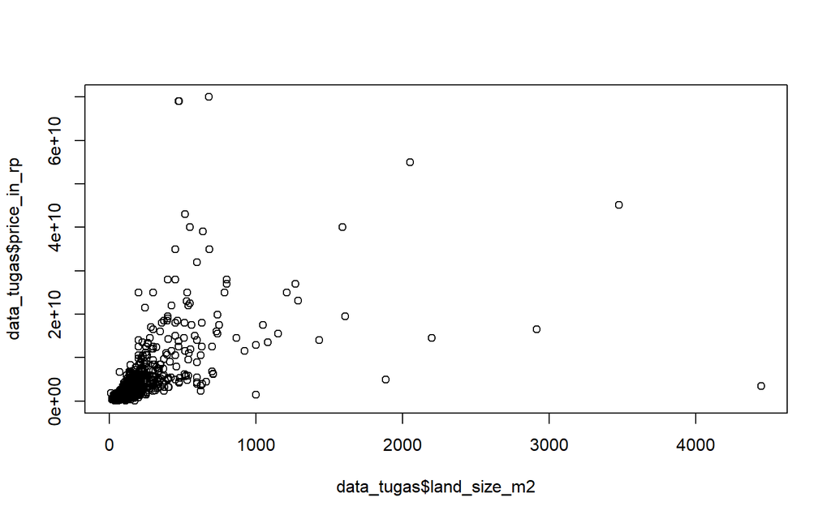

```r
# Tanpa Transformasi
plot(data_tugas$land_size_m2, data_tugas$price_in_rp)
```

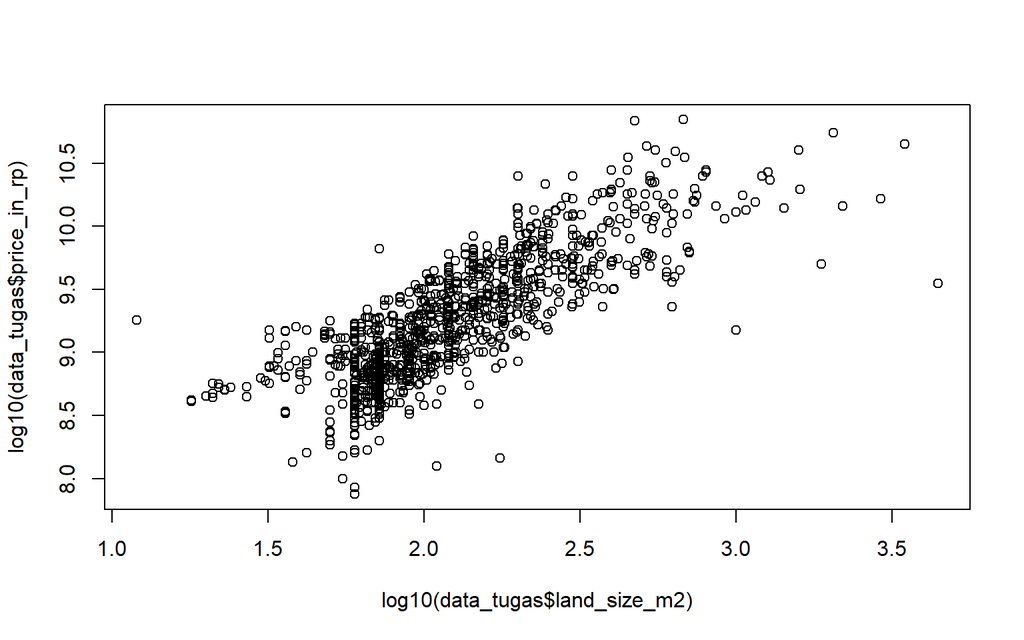

```r
# Dengan Transformasi
plot(log10(data_tugas$land_size_m2), log10(data_tugas$price_in_rp))
```

Tanpa transformasi, data terlihat sangat menumpuk di area luas tanah rendah dan harga murah dengan sebaran yang melebar secara tidak beraturan (heteroskedastisitas). Setelah dilakukan transformasi log-log, hubungan antara luas tanah dan harga rumah menjadi jauh lebih linear dan konsisten, membuktikan bahwa luas tanah adalah prediktor yang kuat bagi harga properti. Keberadaan beberapa outlier pada luas tanah ekstrem menunjukkan adanya properti khusus yang harganya mungkin dipengaruhi oleh faktor prestise atau lokasi di luar ukuran fisik lahan.

### Luas Bangunan

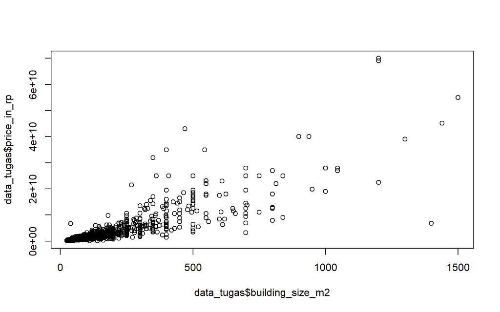

```r
# Tanpa Transformasi
plot(data_tugas$building_size_m2, data_tugas$price_in_rp)
```

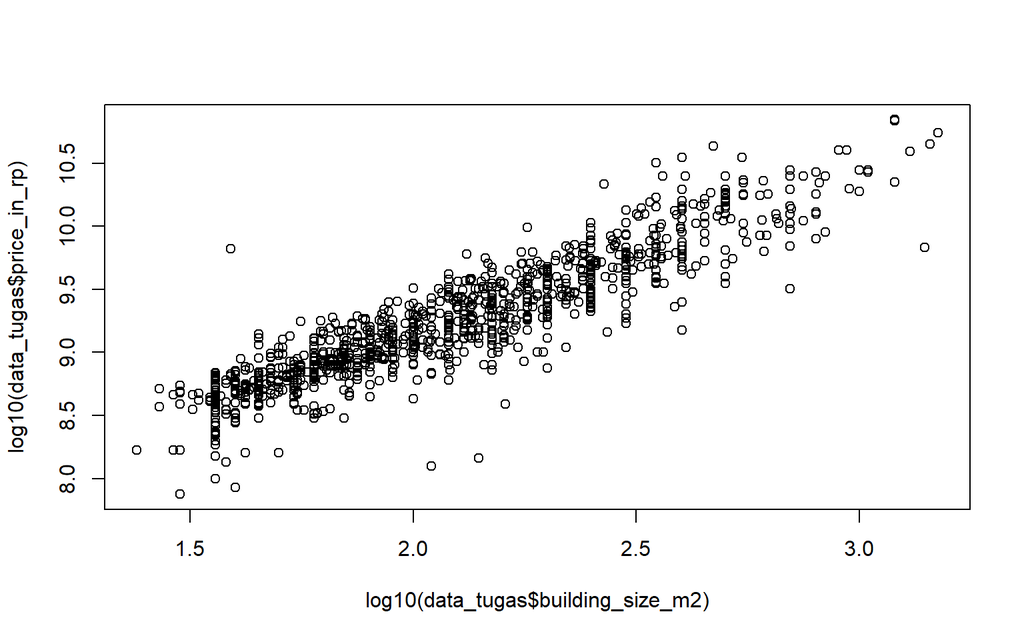

```r
# Dengan Transformasi
plot(log10(data_tugas$building_size_m2), log10(data_tugas$price_in_rp))
```

Visualisasi menunjukkan hubungan positif yang kuat antara luas bangunan dan harga rumah, di mana harga cenderung meningkat secara proporsional seiring bertambahnya luas bangunan. Penggunaan transformasi log-log sangat efektif untuk menormalisasi sebaran data yang awalnya menumpuk di nilai kecil dan membantu memperjelas pola linearitas di antara keduanya. Meskipun terdapat beberapa outlier pada bangunan berukuran sangat besar, tren utama menunjukkan bahwa luas bangunan merupakan indikator harga yang lebih konsisten dibandingkan variabel sebelumnya.

### Umur Bangunan

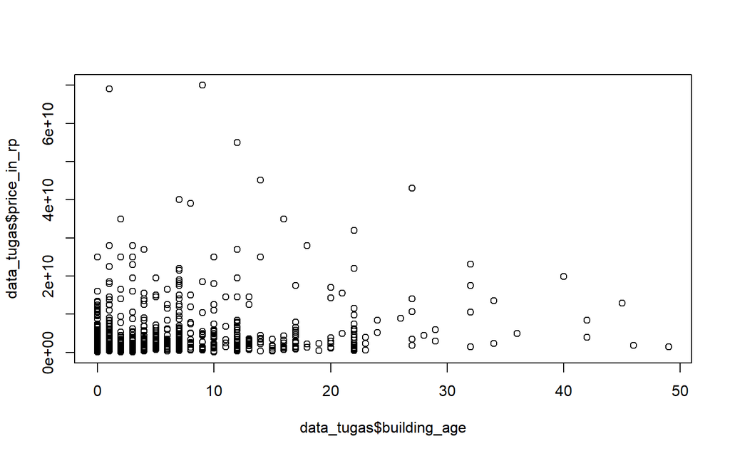

```r
plot(data_tugas$building_age, data_tugas$price_in_rp)
```

## b. matriks korelasi antar variabel

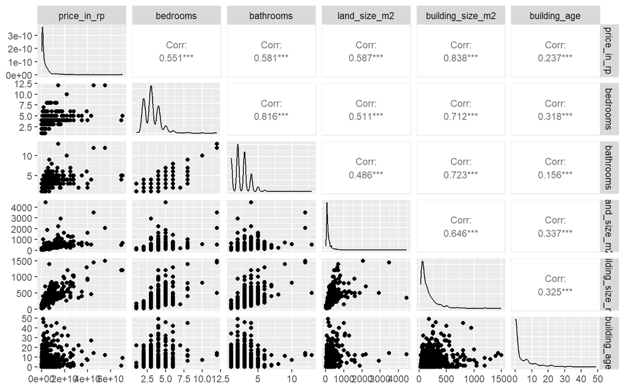

```r
library(GGally)
ggpairs(data_tugas,
        upper = list(continuous = wrap('cor', size = 3)))
```

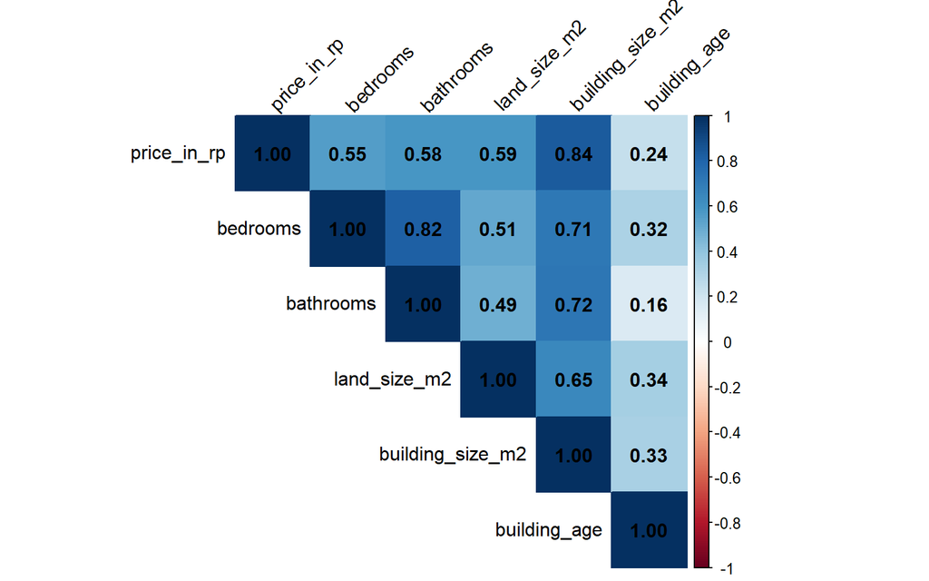

```r
data_numerik <- data_tugas[, sapply(data_tugas, is.numeric)]
matriks_korelasi <- cor(data_numerik, use = "complete.obs")

library(corrplot)
corrplot(matriks_korelasi, method = "color", addCoef.col = "black",
         type = "upper", tl.col = "black", tl.srt = 45)
```

## c. Interpretasi Awal

Hasil analisis menunjukkan bahwa luas bangunan (building_size_m2) merupakan faktor yang paling mendominasi harga rumah dengan korelasi positif yang sangat kuat sebesar 0,84. Variabel fisik lainnya seperti jumlah kamar mandi, luas tanah, dan jumlah kamar tidur juga memiliki hubungan positif moderat (kisaran 0,55 hingga 0,59) terhadap harga, sementara usia bangunan menunjukkan pengaruh yang paling rendah (0,24). Selain itu, terdapat indikasi multikolinearitas yang kuat antara jumlah kamar tidur dan kamar mandi (0,82), yang menandakan kedua variabel tersebut cenderung meningkat secara bersamaan dalam sebuah properti. Secara keseluruhan, karakteristik ukuran fisik bangunan jauh lebih menentukan nilai jual dibandingkan faktor usia atau luas lahan saja.

# 3. Permodelan Regresi

## a. Model Linear Berganda

```r
model1 = lm(formula = price_in_rp ~ ., data = data_tugas)
summary(model1)
```

```
##
## Call:
## lm(formula = price_in_rp ~ ., data = data_tugas)
##
## Residuals:
##        Min         1Q     Median         3Q        Max
## -3.164e+10 -6.481e+08  1.624e+08  4.860e+08  3.590e+10
##
## Coefficients:
##                    Estimate Std. Error t value Pr(>|t|)
## (Intercept)      -110408995  293714569  -0.376 0.707045
## bedrooms         -495947320  146540329  -3.384 0.000734 ***
## bathrooms         -15983187  132007579  -0.121 0.903647
## land_size_m2        2255317     449524   5.017 5.93e-07 ***
## building_size_m2   29680990     861009  34.472  < 2e-16 ***
## building_age      -42398087   15189204  -2.791 0.005322 **
## ---
## Signif. codes:  0 '***' 0.001 '**' 0.01 '*' 0.05 '.' 0.1 ' ' 1
##
## Residual standard error: 3.325e+09 on 1372 degrees of freedom
## Multiple R-squared:  0.7124, Adjusted R-squared:  0.7114
## F-statistic: 679.8 on 5 and 1372 DF,  p-value: < 2.2e-16
```

## b. Persamaan model regresi

$$\text{Harga_Rumah} = -110.408.995 -
495.947.320(\text{X1}) - 15.983.187(\text{X2}) + 2.255.317(\text{X3}) +
29.680.990(\text{X4}) - 42.398.087(\text{X5})$$
Keterangan:

price_in_rp (Y): Harga jual properti dalam satuan Rupiah (IDR).

bedrooms (X1): Jumlah kamar tidur yang tersedia di dalam rumah.

bathrooms (X2): Jumlah kamar mandi yang tersedia di dalam rumah.

land_size_m2 (X3): Luas tanah properti dalam satuan meter persegi (m²).

building_size_m2 (X4): Luas bangunan properti dalam satuan meter persegi (m²).

building_age (X5): Usia bangunan sejak selesai dibangun atau direnovasi terakhir (dalam tahun).

## c. Interpretasi Koefisien Regresi

Interpretasi koefisien regresi tersebut menjelaskan bahwa setiap penambahan satu meter persegi luas bangunan diprediksi akan meningkatkan harga rumah secara signifikan sebesar 29,68 juta rupiah, yang menjadikannya faktor penentu harga paling dominan dalam model ini. Searah dengan hal tersebut, setiap kenaikan satu meter persegi luas tanah juga memberikan kontribusi positif terhadap harga rumah dengan estimasi kenaikan sebesar 2,25 juta rupiah. Sebaliknya, bertambahnya usia bangunan satu tahun justru memberikan dampak negatif berupa penurunan harga sekitar 42,39 juta rupiah, yang mencerminkan adanya penyusutan nilai properti seiring berjalannya waktu.

Tetapi, variabel jumlah kamar tidur dan kamar mandi menunjukkan koefisien negatif yang cukup besar, di mana setiap penambahan satu kamar tidur diprediksi menurunkan harga hingga 495,9 juta rupiah. Namun, angka negatif pada variabel kamar ini sebaiknya tidak diartikan bahwa menambah kamar akan membuat rumah menjadi lebih murah secara riil, melainkan lebih mengindikasikan adanya masalah multikolinearitas yang kuat karena variabel tersebut sudah terwakili oleh luas bangunan. Terakhir, nilai intersept sebesar -110,4 juta rupiah berfungsi sebagai konstanta penyeimbang matematis dalam model dan biasanya tidak diinterpretasikan secara fungsional dalam konteks ekonomi properti karena tidak mungkin sebuah hunian memiliki spesifikasi fisik bernilai nol.

## d. Interpretasi

Berdasarkan hasil analisis regresi, model ini menunjukkan bahwa luas tanah, luas bangunan, jumlah kamar tidur, dan usia bangunan memiliki pengaruh yang signifikan terhadap harga rumah karena nilai p-valuenya berada di bawah 0,05, sedangkan variabel jumlah kamar mandi terbukti tidak signifikan secara statistik. Dilihat dari arah hubungannya, luas tanah dan luas bangunan memberikan kontribusi positif yang meningkatkan nilai properti, namun variabel usia bangunan dan jumlah kamar tidur justru menunjukkan koefisien negatif. Munculnya nilai negatif pada jumlah kamar tidur ini kemungkinan besar disebabkan oleh efek multikolinearitas, mengingat variabel tersebut memiliki korelasi yang sangat kuat dengan luas bangunan dan jumlah kamar mandi.

Secara keseluruhan, model memiliki performa yang cukup baik dengan nilai Adjusted R-squared sebesar 0,7114, yang berarti variabel-variabel prediktor tersebut mampu menjelaskan sekitar 71,14% variasi harga rumah di dalam dataset. Selain itu, hasil uji F dengan p-value yang sangat kecil (kurang dari 2,2e-16) menegaskan bahwa secara simultan atau bersama-sama, seluruh variabel independen yang digunakan memang berpengaruh nyata dalam menentukan harga jual rumah tersebut.

# 4. Pengujian Hipotesis Parameter

```r
model1 = lm(formula = price_in_rp ~ ., data = data_tugas)
summary(model1)
```

```
##
## Call:
## lm(formula = price_in_rp ~ ., data = data_tugas)
##
## Residuals:
##        Min         1Q     Median         3Q        Max
## -3.164e+10 -6.481e+08  1.624e+08  4.860e+08  3.590e+10
##
## Coefficients:
##                    Estimate Std. Error t value Pr(>|t|)
## (Intercept)      -110408995  293714569  -0.376 0.707045
## bedrooms         -495947320  146540329  -3.384 0.000734 ***
## bathrooms         -15983187  132007579  -0.121 0.903647
## land_size_m2        2255317     449524   5.017 5.93e-07 ***
## building_size_m2   29680990     861009  34.472  < 2e-16 ***
## building_age      -42398087   15189204  -2.791 0.005322 **
## ---
## Signif. codes:  0 '***' 0.001 '**' 0.01 '*' 0.05 '.' 0.1 ' ' 1
##
## Residual standard error: 3.325e+09 on 1372 degrees of freedom
## Multiple R-squared:  0.7124, Adjusted R-squared:  0.7114
## F-statistic: 679.8 on 5 and 1372 DF,  p-value: < 2.2e-16
```

## Hipotesis

Hipotesis Uji Parsial (Uji-t)Untuk setiap koefisien $\beta_j$ (dimana $j = 1, 2, ..., k$):
$$\begin{aligned}
H_0 &: \beta_j = 0 \\
H_1 &: \beta_j \neq 0
\end{aligned}$$
Keterangan:

$H_0$ (Hipotesis Nol): Variabel independen ke-$j$ secara parsial tidak memiliki pengaruh yang signifikan terhadap harga rumah.

$H_1$ (Hipotesis Alternatif): Variabel independen ke-$j$ secara parsial memiliki pengaruh yang signifikan terhadap harga rumah.

## Interpretasi

Berdasarkan output regresi tersebut, variabel luas bangunan, luas tanah, jumlah kamar tidur, dan usia bangunan memiliki pengaruh signifikan terhadap harga rumah (p-value < 0,05). Sebaliknya, variabel jumlah kamar mandi terbukti tidak signifikan secara statistik (p-value 0,90). Secara spesifik, luas bangunan dan luas tanah berkontribusi positif dalam meningkatkan harga, sementara usia bangunan dan jumlah kamar tidur justru menunjukkan korelasi negatif dalam model ini.

Secara keseluruhan, model ini memiliki performa yang kuat dengan nilai Adjusted R-squared sebesar 0,7114, yang berarti variabel-variabel tersebut mampu menjelaskan 71,14% variasi harga rumah. Hasil uji F dengan p-value yang sangat kecil juga menegaskan bahwa seluruh variabel independen secara bersama-sama berpengaruh nyata terhadap harga jual properti.

# 5. Diagnostik Model

```r
library(lmtest)
library(car)
library(nortest)
```

## 1. Asumsi Normalitas Residual

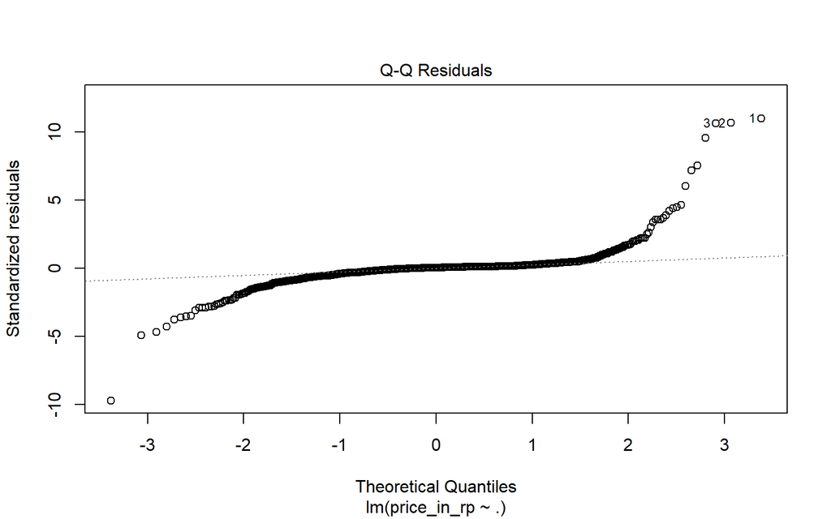

```r
# Secara Visual (QQ-Plot)
plot(model1, which = 2)
```

```r
# Uji Formal (Anderson-Darling)
ad.test(residuals(model1))
```

```
##
##  Anderson-Darling normality test
##
## data:  residuals(model1)
## A = 158.33, p-value < 2.2e-16
```

Interpretasi Visual (Q-Q Plot): Titik-titik pada grafik menyimpang jauh dari garis diagonal (membentuk pola “S” yang ekstrem), terutama pada bagian ujung (tails). Ini menunjukkan bahwa residual tidak mengikuti distribusi normal.

Interpretasi Uji Formal (Anderson-Darling): Diperoleh nilai p-value < 2.2e-16 (jauh lebih kecil dari 0,05). Maka, kita tolak $H_0$ dan menyimpulkan bahwa asumsi normalitas residual tidak terpenuhi.

## 2. Asumsi Homoskedastisitas

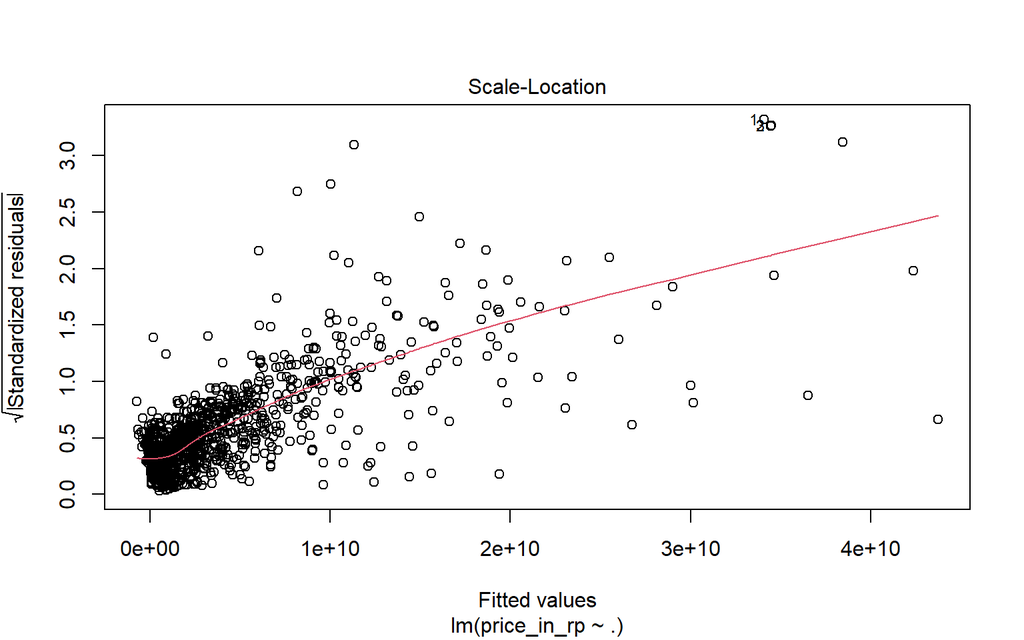

```r
# Secara Visual (Scale-Location Plot)
plot(model1, which = 3)
```

```r
# Uji Formal (Breusch-Pagan Test)
bptest(model1)
```

```
##
##  studentized Breusch-Pagan test
##
## data:  model1
## BP = 337.46, df = 5, p-value < 2.2e-16
```

Interpretasi Visual (Scale-Location Plot): Garis merah pada grafik terlihat menanjak secara konsisten dan sebaran titik-titik semakin melebar seiring bertambahnya nilai prediksi (fitted values). Pola yang membentuk “kipas” atau corong ini mengindikasikan bahwa varians residual tidak konstan atau terjadi gejala heteroskedastisitas.

Interpretasi Uji Formal (Breusch-Pagan Test): Berdasarkan hasil uji, diperoleh nilai p-value < 2.2e-16. Karena nilai p-value jauh lebih kecil dari tingkat signifikansi $\alpha = 0,05$, maka kita tolak $H_0$. Ini berarti terdapat bukti statistik yang sangat kuat bahwa model mengalami masalah heteroskedastisitas.

## 3. Asumsi Independensi Residual (Autokorelasi)

```r
# Uji Durbin-Watson
dwtest(model1)
```

```
##
##  Durbin-Watson test
##
## data:  model1
## DW = 0.95848, p-value < 2.2e-16
## alternative hypothesis: true autocorrelation is greater than 0
```

Nilai Statistik DW (0,95848): Nilai Durbin-Watson berada di kisaran 0 hingga 4. Nilai yang mendekati 2 menunjukkan tidak adanya autokorelasi. Karena nilai (0,95) jauh di bawah 2, ini mengindikasikan adanya autokorelasi positif antar residual.

Nilai p-value (< 2.2e-16): Karena p-value jauh lebih kecil dari taraf signifikansi $\alpha = 0,05$, maka kita tolak $H_0$.

Kesimpulan: Asumsi independensi residual tidak terpenuhi. Artinya, terdapat pola ketergantungan antar data pengamatan (residual satu data dipengaruhi oleh data lainnya).

## 4. Multikolinieritas

```r
# Menghitung nilai VIF (Variance Inflation Factor)
# VIF > 10 menunjukkan adanya multikolinieritas serius
vif(model1)
```

```
##         bedrooms        bathrooms     land_size_m2 building_size_m2
##         3.558688         3.656744         1.780683         2.957143
##     building_age
##         1.253456
```

Karena semua nilai VIF < 10, maka dapat disimpulkan bahwa tidak terdapat hubungan linear yang sangat kuat antar variabel independen yang dapat mengganggu estimasi koefisien regresi. Variabel-variabel tersebut masih layak digunakan secara bersamaan dalam model.

## 5. Outlier, Leverage, dan Amatan Berpengaruh

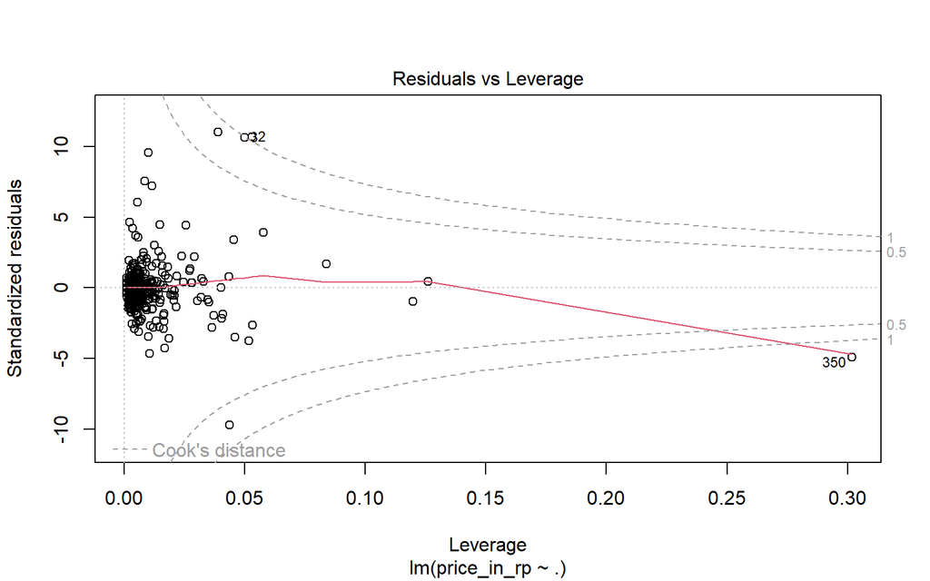

```r
# Secara Visual (Residuals vs Leverage)
plot(model1, which = 5)
```

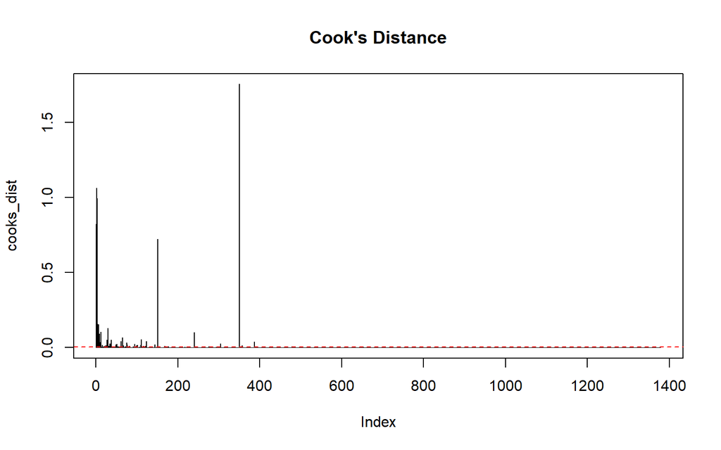

```r
# Menghitung Cook's Distance untuk amatan berpengaruh
# Amatan dengan Cook's D > 4/n perlu diperhatikan
cooks_dist <- cooks.distance(model1)
plot(cooks_dist, type = "h", main = "Cook's Distance")
abline(h = 4/nrow(data_tugas), col = "red", lty = 2)
```

```r
# Melihat 5 data dengan pengaruh paling besar
tail(sort(cooks_dist), 5)
```

```
##       151         1         3         2       350
## 0.7208562 0.8201988 0.9930748 1.0622856 1.7534995
```

Cook’s Distance: Sebagian besar data berada di bawah garis ambang batas (garis putus-putus merah), namun terdapat beberapa yang sangat tinggi.

Nilai Cook’s Distance tertinggi mencapai lebih dari 1,5, yang jauh melampaui aturan praktis $4/n$. Ini mengonfirmasi adanya amatan yang terlalu dominan dalam menentukan hasil model.

5 Data Paling Berpengaruh:i ndeks data yang paling bermasalah, yaitu indeks 151, 1, 3, 2, dan 350. Amatan nomor 350 adalah yang paling ekstrem dengan nilai Cook’s distance sebesar 1,75.

# 6. Interpretasi Hasil Diagnostik

## Analisis Pelanggaran Asumsi

Berdasarkan hasil pengujian diagnostik, model regresi yang digunakan masih mengalami beberapa pelanggaran terhadap asumsi klasik yang cukup penting. Pada uji normalitas, residual tidak mengikuti distribusi normal (ditunjukkan oleh p-value < 0,05), yang juga terlihat dari pola berbentuk “S” pada Q-Q Plot. Selain itu, terdapat indikasi heteroskedastisitas yang cukup kuat, di mana varians residual tidak konstan dan cenderung membentuk pola menyerupai corong pada grafik Scale-Location.

Masalah lain yang ditemukan adalah adanya autokorelasi positif berdasarkan hasil uji Durbin-Watson, yang mengindikasikan bahwa terdapat hubungan antar residual pada observasi yang berdekatan. Di samping itu, model juga dipengaruhi oleh beberapa data yang bersifat ekstrem atau berpengaruh (outlier), khususnya pada observasi ke-350 yang memiliki nilai Cook’s Distance yang tinggi. Namun demikian, untuk asumsi non-multikolinieritas, model ini sudah memenuhi kriteria dengan baik karena seluruh variabel memiliki nilai VIF di bawah 10.

## Metode Penanganan Permasalahan

terdapat beberapa pendekatan yang secara teori dapat digunakan untuk mengatasi permasalahan tersebut. Salah satunya adalah melakukan transformasi variabel, misalnya dengan mengubah variabel dependen (Harga) ke dalam bentuk logaritma (log atau ln). Transformasi ini dapat membantu mengurangi ketidakseimbangan distribusi data serta mengatasi heteroskedastisitas.

Selain itu, metode Robust Regression juga dapat digunakan apabila terdapat banyak outlier yang tidak ingin dihapus, karena metode ini lebih tahan terhadap pengaruh data ekstrem dibandingkan metode OLS biasa. Untuk mengatasi heteroskedastisitas secara lebih spesifik, pendekatan Weighted Least Squares (WLS) dapat diterapkan dengan memberikan bobot yang berbeda pada tiap observasi sesuai dengan variansnya.

Langkah lain yang bisa dilakukan adalah melakukan pembersihan data, terutama pada observasi yang teridentifikasi sebagai outlier melalui Cook’s Distance. Jika data tersebut merupakan kesalahan atau tidak representatif, maka penghapusan data dapat dipertimbangkan. Terakhir, untuk mengatasi autokorelasi, metode Generalized Least Squares (GLS) dapat digunakan agar struktur korelasi dalam residual dapat dimodelkan dengan lebih baik.

# 7. Kesimpulan

Berdasarkan hasil analisis regresi yang telah dilakukan, model memiliki performa yang cukup baik dengan nilai Adjusted R-squared sekitar 71%, yang menunjukkan bahwa sebagian besar variasi harga rumah dapat dijelaskan oleh variabel-variabel prediktor yang digunakan. Selain itu, hasil uji F juga menunjukkan bahwa secara simultan hampir seluruh variabel independen berpengaruh signifikan terhadap harga rumah.

Secara umum, hubungan antara variabel respon dan variabel prediktor menunjukkan bahwa luas bangunan dan luas tanah memiliki pengaruh positif terhadap harga rumah, sehingga semakin besar ukuran properti maka harga cenderung meningkat. Sebaliknya, usia bangunan berpengaruh negatif, yang berarti semakin tua bangunan maka harga cenderung menurun. Variabel jumlah kamar tidur juga menunjukkan arah negatif, namun hal ini kemungkinan disebabkan oleh adanya multikolinearitas dengan variabel lain, sedangkan jumlah kamar mandi tidak berpengaruh signifikan terhadap harga rumah.

Namun, berdasarkan hasil diagnostik model, ditemukan beberapa pelanggaran asumsi klasik. Residual tidak berdistribusi normal, terdapat heteroskedastisitas yang cukup kuat, serta indikasi autokorelasi antar residual. Selain itu, terdapat beberapa outlier atau amatan berpengaruh, khususnya pada data dengan nilai Cook’s Distance yang tinggi, yang dapat mempengaruhi hasil estimasi model. Meskipun demikian, asumsi non-multikolinieritas telah terpenuhi dengan baik.

Secara keseluruhan, meskipun model mampu menjelaskan hubungan antara variabel dengan cukup baik, hasil inferensi perlu diinterpretasikan dengan hati-hati karena adanya pelanggaran asumsi yang dapat mempengaruhi keakuratan dan keandalan model.